# Machine Learning Project - Week 4

5/20/2017

## A. Introduction:

The objective of this report is to “predict” the way in which the 6 participants performed the dumbbell exercise. The dumbbell exercises was performed in 5 styles (referred as “classe”). Each style has 10 repetitions exercises being performed. The exercises was recorded using wearable devices. The data sets provided contains 2 types: “Training” and “Testing” from the following web link:

1. Training Data: https://d396qusza40orc.cloudfront.net/predmachlearn/pml-training.csv
2. Test Data: https://d396qusza40orc.cloudfront.net/predmachlearn/pml-testing.csv

## B. Data Preparation and Exploration:

Preparation begins with loading the necessary libraries. Once the “raw data sets” are downloaded from the given web link source, we performed data exploration. The dimension of the raw data sets are as follows:

1. Raw Training(train1.raw): 19622 rows/records and 160 columns/fields
2. Raw Testing (test1.raw): 20 rows/records and 160 columns/fields

1. Clean Training(train1.clean): 19622 rows/records and 53 columns/fields
2. Clean Testing(test1. clean): 20 rows/records and 53 columns/fields

```r
library(dplyr)
library(ggplot2)
library(caret)
library(kernlab)
library(randomForest)
library(rpart)
library(rpart.plot)
library(e1071)
```

```r
# set the URL for the download
train1.url <- "https://d396qusza40orc.cloudfront.net/predmachlearn/pml-training.csv"
test1.url <- "https://d396qusza40orc.cloudfront.net/predmachlearn/pml-testing.csv"

# download the datasets
train1.raw <- read.csv(url(train1.url), na.strings = c("NA", ""))
test1.raw <- read.csv(url(test1.url), na.strings = c("NA", ""))

dim(train1.raw)
```

```
## [1] 19622   160
```

```r
dim(test1.raw)
```

```
## [1]  20 160
```

```r
str(train1.raw)
```

[output not shown]

[output cut: 86 more lines]

```r
##Remove NA column & column 1-7 as identifier column
train1.clean <- train1.raw[, colSums(is.na(train1.raw)) == 0]
train1.clean <- train1.clean[, -c(1:7)]

test1.clean <- test1.raw[, colSums(is.na(test1.raw)) == 0]
test1.clean <- test1.clean[, -c(1:7)]

dim(train1.clean)
```

```
## [1] 19622    53
```

```r
dim(test1.clean)
```

```
## [1] 20 53
```

## C. Data Partitioning:

Data partitioning was performed into the “clean training data set”, by allocating “70% for train and 30% for test”. Note that the “clean testing data set is excluded in data partition. The dimension of the clean training data set after data partitioning are as follows:

1. Partition Training: 13737 rows/records and 53 columns/fields
2. Partition Testing: 5885 rows/records and 53 columns/fields

```r
inTrain<-createDataPartition(y=train1.clean$classe, p=0.7, list = FALSE)
trainset<-train1.clean[inTrain,]
testset<-train1.clean[-inTrain,]
dim(trainset); dim(testset)
```

```
## [1] 13737    53
```

```
## [1] 5885   53
```

## D. Method 1: Random Forest:

```r
set.seed(6666)
mod1.rf <- randomForest(classe~.,method="class", data=trainset,
                trControl= trainControl(method = "cv",number = 4,allowParallel = TRUE)
            )

cv.rf<-predict(mod1.rf, testset)
c1<-confusionMatrix(testset$classe, cv.rf)
c1
```

```
## Confusion Matrix and Statistics
##
##           Reference
## Prediction    A    B    C    D    E
##          A 1673    0    0    0    1
##          B    4 1132    3    0    0
##          C    0   10 1014    2    0
##          D    0    0   10  954    0
##          E    0    0    3    0 1079
##
## Overall Statistics
##
##                Accuracy : 0.9944
##                  95% CI : (0.9921, 0.9961)
##     No Information Rate : 0.285
##     P-Value [Acc > NIR] : < 2.2e-16
##
##                   Kappa : 0.9929
##  Mcnemar's Test P-Value : NA
##
## Statistics by Class:
##
##                      Class: A Class: B Class: C Class: D Class: E
## Sensitivity            0.9976   0.9912   0.9845   0.9979   0.9991
## Specificity            0.9998   0.9985   0.9975   0.9980   0.9994
## Pos Pred Value         0.9994   0.9939   0.9883   0.9896   0.9972
## Neg Pred Value         0.9991   0.9979   0.9967   0.9996   0.9998
## Prevalence             0.2850   0.1941   0.1750   0.1624   0.1835
## Detection Rate         0.2843   0.1924   0.1723   0.1621   0.1833
## Detection Prevalence   0.2845   0.1935   0.1743   0.1638   0.1839
## Balanced Accuracy      0.9987   0.9949   0.9910   0.9979   0.9992
```

```r
# prediction based on random forest
#predict1.rf <- predict(mod1.rf, newdata=testset)
#confMatRandForest <- confusionMatrix(predict1.rf, testset$classe)
#confMatRandForest
```

## E.Method 2: Decision Tree:

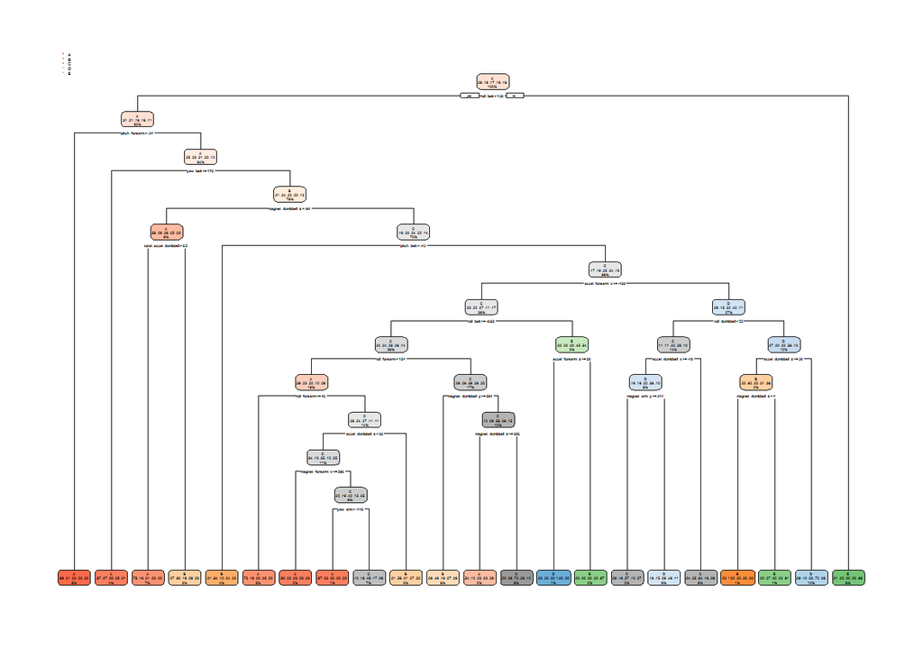

```r
mod1.dc <- rpart(classe ~ ., data=testset, method="class")
rpart.plot(mod1.dc)
```

```r
# prediction based on Decision Tree
predict1.dc <- predict(mod1.dc, newdata=testset, type="class")
confMatDecTree <- confusionMatrix(predict1.dc, testset$classe)
confMatDecTree
```

```
## Confusion Matrix and Statistics
##
##           Reference
## Prediction    A    B    C    D    E
##          A 1440  157    9   48   49
##          B   41  708  128   68  187
##          C   68  158  842  180  123
##          D  117  112   47  667   75
##          E    8    4    0    1  648
##
## Overall Statistics
##
##                Accuracy : 0.7315
##                  95% CI : (0.72, 0.7428)
##     No Information Rate : 0.2845
##     P-Value [Acc > NIR] : < 2.2e-16
##
##                   Kappa : 0.6605
##  Mcnemar's Test P-Value : < 2.2e-16
##
## Statistics by Class:
##
##                      Class: A Class: B Class: C Class: D Class: E
## Sensitivity            0.8602   0.6216   0.8207   0.6919   0.5989
## Specificity            0.9375   0.9107   0.8911   0.9287   0.9973
## Pos Pred Value         0.8456   0.6254   0.6142   0.6552   0.9803
## Neg Pred Value         0.9440   0.9093   0.9592   0.9390   0.9169
## Prevalence             0.2845   0.1935   0.1743   0.1638   0.1839
## Detection Rate         0.2447   0.1203   0.1431   0.1133   0.1101
## Detection Prevalence   0.2894   0.1924   0.2330   0.1730   0.1123
## Balanced Accuracy      0.8989   0.7661   0.8559   0.8103   0.7981
```

### F. Apply Random Forest into Clean Test Data Set:

The accuracy results above indicates that Random Forest method gives higher accuracy as compared to Decision Tree. Therefore, prediction was applied into Clean Test Data using Random Forrest Method. The prediction result is shown below.

```r
predict1.final <- predict(mod1.rf, newdata=test1.clean)
predict1.final
```

```
##  1  2  3  4  5  6  7  8  9 10 11 12 13 14 15 16 17 18 19 20
##  B  A  B  A  A  E  D  B  A  A  B  C  B  A  E  E  A  B  B  B
## Levels: A B C D E
```